# Visualizing FordGoBike Data

## by Maciej Szymczak

## Investigation Overview

Investigating the Ford GoBike System, I wanted analyze the most common Customer and Subscriber behaviors and characteristics, specifically how user type, time an distance impact the system.

## Dataset Overview

The system was originally launched as Bay Area Bike Share in August 2013. At launch, it became the first regional bicycle sharing system deployed on the West Coast of the United States and also the first regional system in the U.S. that services more than just a single city or adjacent cities. The original system was described as a pilot program and consisted of only 700 bicycles with 70 stations, 34 of which were in San Francisco. The program's original administrator was the Bay Area Air Quality Management District, which handed off the public management of the system to the Metropolitan Transportation Commission in 2016.

In September 2016, Ford announced that it would sponsor the system with a contribution of $50 million, finally enabling the planned expansion from the original system's 700 bicycles to 7000. On June 28, 2017, the system officially re-launched as Ford GoBike. As of January 2018, the Bay Wheels system had about 10,000 annual subscribers, over 2,600 bicycles in 262 stations across San Francisco, East Bay and San Jose.

In June 2019, after Motivate's acquisition by Lyft, the system rebranded to Bay Wheels and dropped the Ford naming.

I will be analyzing the 2018 dataset.

## Distribution of Ford GoBike users

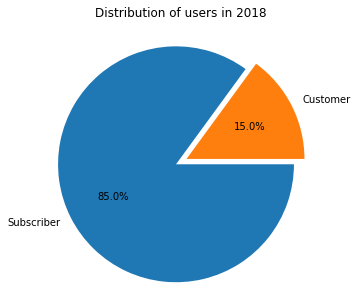

```python
plt.figure(figsize=[14,5])

plt.subplot(1, 2, 1);
sorted_vals = Ford2018.user_type.value_counts()/Ford2018.shape[0];
plt.pie(sorted_vals, explode=[0, 0.1], labels=sorted_vals.index, counterclock=False, autopct='%1.1f%%');
plt.title('Distribution of users in 2018')
plt.axis('square');
```

## Distribution of riding times

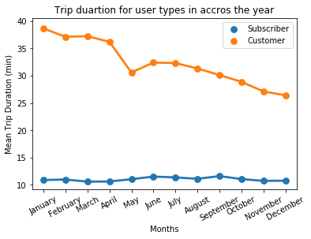

```python
sb.pointplot(data = Ford2018, x = 'month', y = 'duration_min', hue = 'user_type', ci=None)
plt.title('Trip duartion for user types in accros the year')
plt.ylabel('Mean Trip Duration (min)')
plt.xlabel('Months')
plt.xticks(rotation = 28)
plt.legend()
plt.show();
```

## Distribution of rides (days and months)

With these two visualisations we can see that there are a lot more bike rides on week days (Mon - Fri), and also in the warmer moths (May - October). We can also see than when adding a user type filter we can see that Customers are using the system sightly more often on weekends then on weekdays.

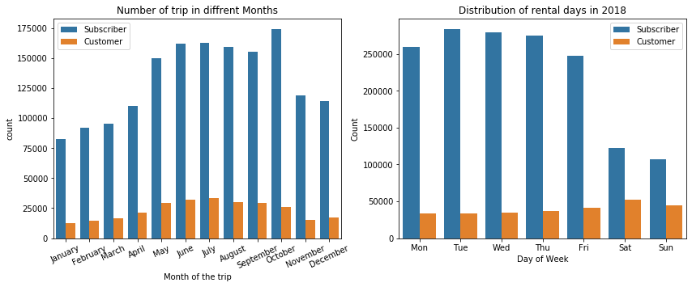

```python
plt.figure(figsize=[14,5])

plt.subplot(1, 2, 1)
sb.countplot(data=Ford2018, x='month', hue='user_type');
plt.xlabel('Month of the trip')
plt.title('Number of trip in diffrent Months')
plt.xticks(rotation = 25)
plt.legend();

plt.subplot(1, 2, 2)
sb.countplot(data=Ford2018, x='day', hue='user_type');
plt.title('Distribution of rental days in 2018')
plt.xlabel('Day of Week');
plt.ylabel('Count')
plt.legend();
```